# Week 3 - Introduction to Data Analysis

ETC1010-5510

## Exercise 2: Exploring Pedestrian Counts

> Open data-viz2.Rmd

> In here, we’ll explore trends in pedestrian counts for Melbourne Central station. To solve this exercise, fill in the blanks and then knit the final document.

### Load packages and get data

```r
library(tidyverse)
library(rwalkr)
library(lubridate)
```

### Filter out sensor data for Melbourne Central and store in a variable called `walk`

```r
walk_all <- melb_walk_fast(year = 2019)

walk <- walk_all %>% filter(Sensor == "Melbourne Central")

# write_csv(walk, path = "exercises/3b/data/walk_2019.csv")
# write_csv(walk, path = "data/walk_2019.csv")
```

### Read the data from “data” folder and convert to “tidy” format

```r
walk <- read_csv("data/walk_2019.csv")
walk
```

```
## # A tibble: 8,760 x 5
##    Sensor            Date_Time           Date        Time Count
##    <chr>             <dttm>              <date>     <dbl> <dbl>
##  1 Melbourne Central 2018-12-31 13:00:00 2019-01-01     0    NA
##  2 Melbourne Central 2018-12-31 14:00:00 2019-01-01     1    NA
##  3 Melbourne Central 2018-12-31 15:00:00 2019-01-01     2    NA
##  4 Melbourne Central 2018-12-31 16:00:00 2019-01-01     3    NA
##  5 Melbourne Central 2018-12-31 17:00:00 2019-01-01     4    NA
##  6 Melbourne Central 2018-12-31 18:00:00 2019-01-01     5    NA
##  7 Melbourne Central 2018-12-31 19:00:00 2019-01-01     6    NA
##  8 Melbourne Central 2018-12-31 20:00:00 2019-01-01     7    NA
##  9 Melbourne Central 2018-12-31 21:00:00 2019-01-01     8    NA
## 10 Melbourne Central 2018-12-31 22:00:00 2019-01-01     9    NA
## # … with 8,750 more rows
```

### Conversion to Tidy data: Add new variables to data: `month` and `wday`

```r
walk_tidy <- walk %>%
  mutate(month = month(Date,  label = TRUE, abbr = TRUE),
         wday = wday(Date, label = TRUE, abbr = TRUE, week_start = 1))
walk_tidy
```

```
## # A tibble: 8,760 x 7
##    Sensor            Date_Time           Date        Time Count month wday
##    <chr>             <dttm>              <date>     <dbl> <dbl> <ord> <ord>
##  1 Melbourne Central 2018-12-31 13:00:00 2019-01-01     0    NA Jan   Tue
##  2 Melbourne Central 2018-12-31 14:00:00 2019-01-01     1    NA Jan   Tue
##  3 Melbourne Central 2018-12-31 15:00:00 2019-01-01     2    NA Jan   Tue
##  4 Melbourne Central 2018-12-31 16:00:00 2019-01-01     3    NA Jan   Tue
##  5 Melbourne Central 2018-12-31 17:00:00 2019-01-01     4    NA Jan   Tue
##  6 Melbourne Central 2018-12-31 18:00:00 2019-01-01     5    NA Jan   Tue
##  7 Melbourne Central 2018-12-31 19:00:00 2019-01-01     6    NA Jan   Tue
##  8 Melbourne Central 2018-12-31 20:00:00 2019-01-01     7    NA Jan   Tue
##  9 Melbourne Central 2018-12-31 21:00:00 2019-01-01     8    NA Jan   Tue
## 10 Melbourne Central 2018-12-31 22:00:00 2019-01-01     9    NA Jan   Tue
## # … with 8,750 more rows
```

## Answer the following questions:

### Q1. Generate a plot for *monthly* pedestrian counts. Use `month` and `Count`.

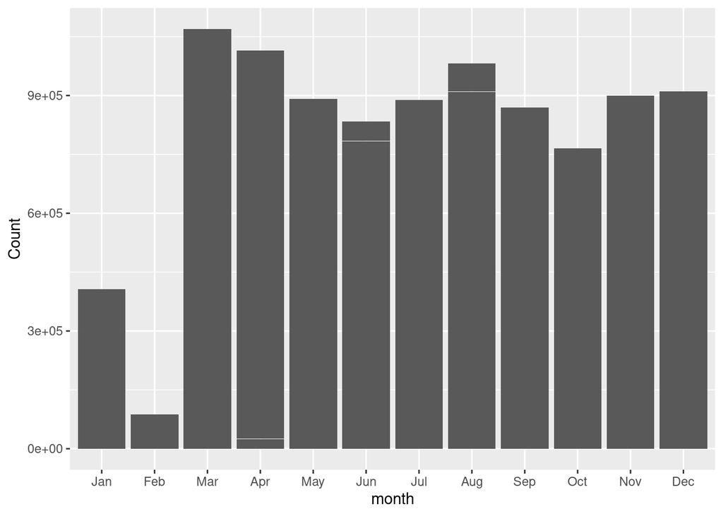

```r
ggplot(walk_tidy,
       aes(x = month,
           y = Count)) +
  geom_col()
```

### Q2. Similarly, generate a plot for *weekly* pedestrian counts.

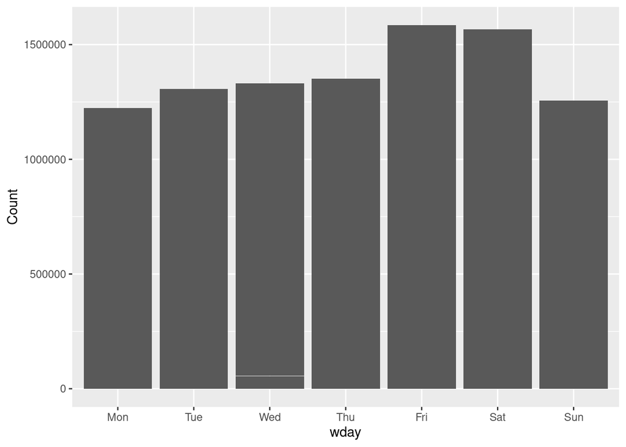

```r
ggplot(walk_tidy,
       aes(x = wday,
           y = Count)) +
  geom_col()
```

### Q3. Create above graphs (*monthly, weekly and daily* counts) for Birrarung Marr.

> First, let’s pull the 2019 data for the sensor Birrarung Marr. Transform data into tidy form.

> Hint: Look at the similar code for Melbourne Central above.

```r
# filter data for Birrarung Marr
walk_birra <- walk_all %>% filter(Sensor == "Birrarung Marr")

# transform to tidy data; create new columns: `month` and `wday`
walk_birra_tidy <- walk_birra %>%
  mutate(month = month(Date,  label = TRUE, abbr = TRUE),
         wday = wday(Date, label = TRUE, abbr = TRUE, week_start = 1))
walk_birra_tidy
```

```
## # A tibble: 8,760 x 7
##    Sensor         Date_Time           Date        Time Count month wday
##    <chr>          <dttm>              <date>     <int> <int> <ord> <ord>
##  1 Birrarung Marr 2019-01-01 00:00:00 2019-01-01     0    NA Jan   Tue
##  2 Birrarung Marr 2019-01-01 01:00:00 2019-01-01     1  2733 Jan   Tue
##  3 Birrarung Marr 2019-01-01 02:00:00 2019-01-01     2  1086 Jan   Tue
##  4 Birrarung Marr 2019-01-01 03:00:00 2019-01-01     3   571 Jan   Tue
##  5 Birrarung Marr 2019-01-01 04:00:00 2019-01-01     4   208 Jan   Tue
##  6 Birrarung Marr 2019-01-01 05:00:00 2019-01-01     5    83 Jan   Tue
##  7 Birrarung Marr 2019-01-01 06:00:00 2019-01-01     6    46 Jan   Tue
##  8 Birrarung Marr 2019-01-01 07:00:00 2019-01-01     7    48 Jan   Tue
##  9 Birrarung Marr 2019-01-01 08:00:00 2019-01-01     8    49 Jan   Tue
## 10 Birrarung Marr 2019-01-01 09:00:00 2019-01-01     9    65 Jan   Tue
## # … with 8,750 more rows
```

> Next, create plots:

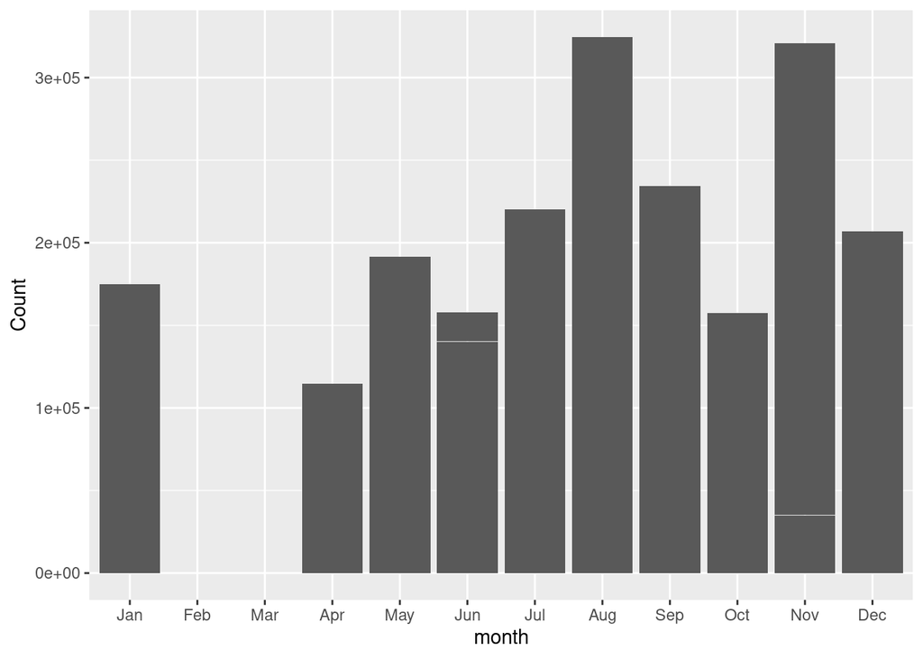

```r
# Monthly counts:
ggplot(walk_birra_tidy,
       aes(x = month,
           y = Count)) +
  geom_col()
```

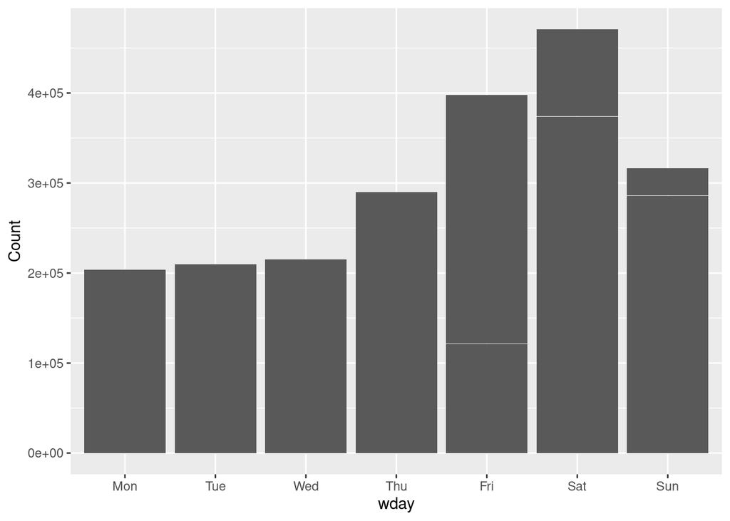

```r
# Weekly counts:
ggplot(walk_birra_tidy,
       aes(x = wday,
           y = Count)) +
  geom_col()
```

> Bar plots do not provide sufficient insights:
> - There might be a different number of days of the week over the year.
> - This means that simply summing the counts might lead to a misinterpretation of pedestrian patterns.
> - Similarly, months have different numbers of days.

### Q4. Generate a line-plot for *daily* pedestrian counts. Here, we’ll use `geom_line()` and `group` aesthetic to group the lines.

> Hint: Use `Time` and `Count` as aesthetics.

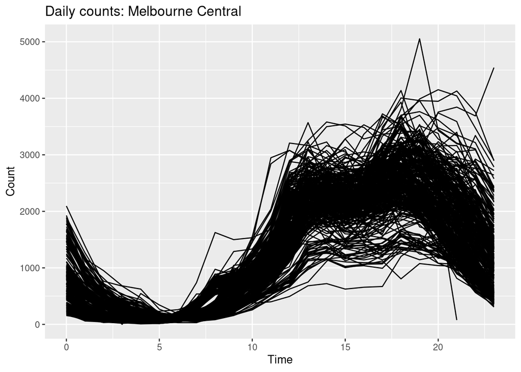

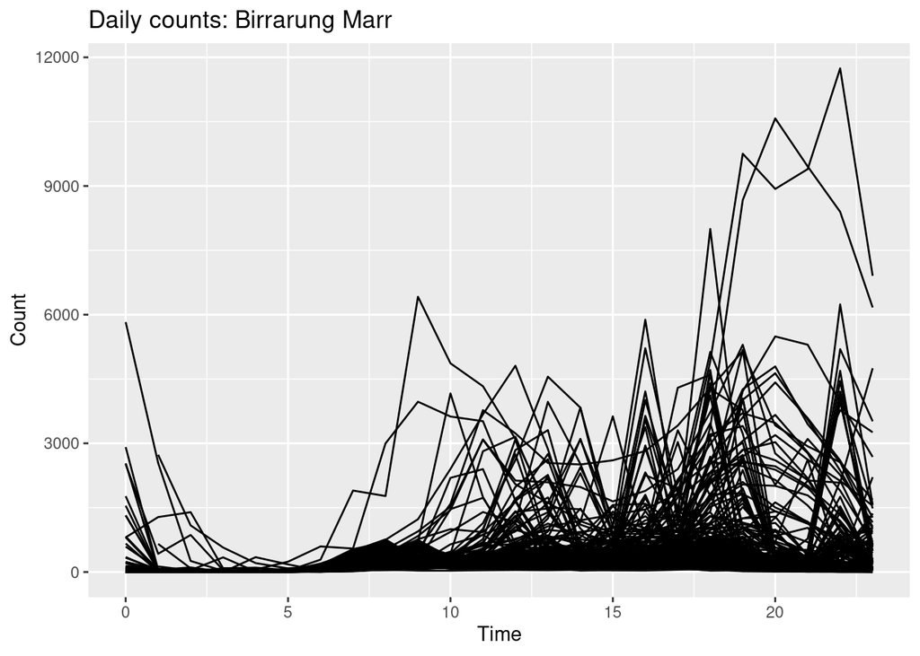

```r
# Daily counts- Melbourne central
ggplot(walk_tidy,
       aes(x = Time,
           y = Count,
           group = Date)) +
  geom_line() +
  ggtitle("Daily counts: Melbourne Central")
ggplot(walk_birra_tidy,
       aes(x = Time,
           y = Count,
           group = Date)) +
  geom_line() +
  ggtitle("Daily counts: Birrarung Marr")
```

> Line charts reveal interesting patterns from daily pedestrian counts.

### **Is there the same *daily* pattern as observed at Melbourne Central? If not, how does it differ?**

> It is hard to tell because of different y-scales. The y-scales need to be the same to make a valid comparison.

### Q5. What are the number of pedestrians per day?

> Hint: Refer to Workshop slides

```r
walk_day <- walk_tidy %>%
  group_by(Date) %>%
  summarise(day_count = sum(Count, na.rm = TRUE))
walk_day
```

```
## # A tibble: 365 x 2
##    Date       day_count
##  * <date>         <dbl>
##  1 2019-01-01         0
##  2 2019-01-02         0
##  3 2019-01-03         0
##  4 2019-01-04         0
##  5 2019-01-05     16173
##  6 2019-01-06       627
##  7 2019-01-07         0
##  8 2019-01-08         0
##  9 2019-01-09     17173
## 10 2019-01-10     16948
## # … with 355 more rows
```

### Q6. What are the average number of pedestrians per weekday?

> Hint: Refer to Workshop slides

```r
walk_day %>%
  mutate(wday = wday(Date, label = TRUE, abbr = TRUE, week_start = 1)) %>%
  group_by(wday) %>%
  summarise(m = mean(day_count, na.rm = TRUE),
            s = sd(day_count, na.rm = TRUE))
```

```
## # A tibble: 7 x 3
##   wday       m      s
## * <ord>  <dbl>  <dbl>
## 1 Mon   23533.  9408.
## 2 Tue   24668.  9733.
## 3 Wed   25582.  9534.
## 4 Thu   25998. 10795.
## 5 Fri   30491. 11659.
## 6 Sat   30120. 10633.
## 7 Sun   24142.  9579.
```

## Exercise 3: More Data Visualisation using Calendar plots

> We’ll continue in this same .Rmd

> Let’s combine the Birrarung Marr data with Melbourne central data (walk) using `bind_rows()`. Or even subset the original data that has all the obsercations into something that has melbourne central AND birrarung marr. There are many ways to get to the same answer.

> Let’s bind the two Sensors- Melbourne central and Birrarung Marr together

```r
walk_both <- bind_rows(walk_tidy,
                       walk_birra_tidy)
```

## Answer the following questions:

### Q1. Is there the same *daily* pattern as observed at Melbourne Central? If not, how does it differ? Can you provide reason for the different daily pattern?

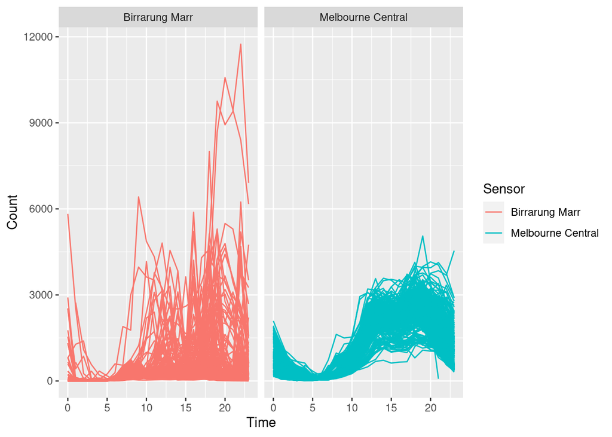

```r
ggplot(walk_both,
        aes(x = Time,
            y = Count,
           colour = Sensor,
           group= Date)) +
     geom_line() +
  facet_wrap(~Sensor)
```

> No. While pedestrian counts at Melbourne Central follow a strict pattern, Birrarung Marr has a lot of variation.

> This could be because of the varied nature of activities at the two Sensor locations. Melbourne Central hosts activities such as office commutes, student’s commute, shopping, restaurants etc.

> Birrarung Marr Park on the other hand hosts events and festivals such as Moomba fest! The park also provides walking, cycle access and other recreational activities.

### Q2. Can you detect special events, like the Moomba Festival, based on pedestrian counts?

> We can do this using Calendar plots. Use your Google skills to find out Moomba Fest 2019 dates and observe pedestrian trends.

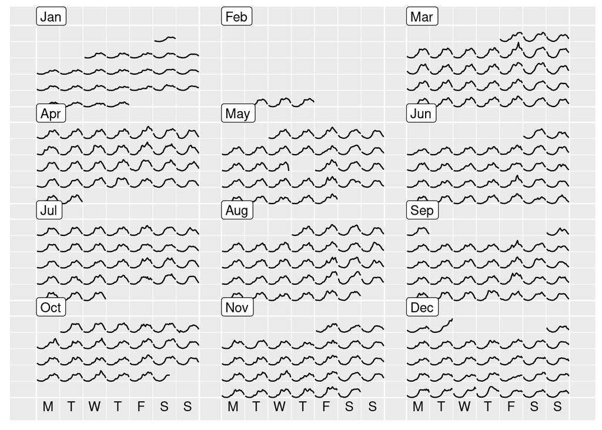

```r
library(sugrrants)
walk_tidy_calendar <-
  frame_calendar(walk_tidy,
                 x = Time,
                 y = Count,
                 date = Date,
                 nrow = 4)
p1 <- ggplot(walk_tidy_calendar,
       aes(x = .Time,
           y = .Count,
           group = Date)) +
  geom_line()
prettify(p1)
```

> Also, look at the pedestrian counts on 31st Dec. What do you observe?

### Q3. How do the calendar plots compare for Melbourne Central and Birrarung Marr?

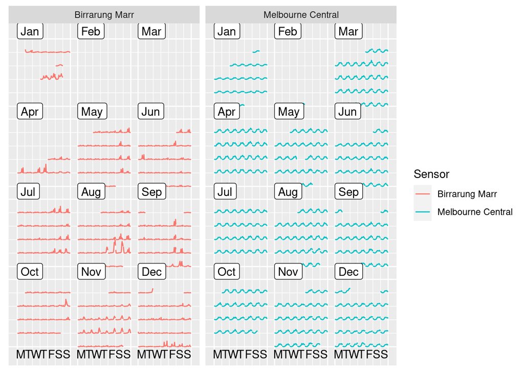

```r
walk_both_tidy_calendar <-
  frame_calendar(walk_both,
                 x = Time,
                 y = Count,
                 date = Date,
                 nrow = 4)

p2 <- ggplot(walk_both_tidy_calendar,
       aes(x = .Time,
           y = .Count,
           colour= Sensor,
           group = Date)) +
  geom_line() +
  facet_wrap(~Sensor)
prettify(p2)
```

### Q4. Join holidays data with pedestrian counts and observe trends. Can you match these with known events, found from web searching?

```r
library(tsibble)
library(sugrrants)
library(timeDate)
vic_holidays <- holiday_aus(2019, state = "VIC")
vic_holidays
```

```
## # A tibble: 12 x 2
##    holiday          date
##    <chr>            <date>
##  1 New Year's Day   2019-01-01
##  2 Australia Day    2019-01-28
##  3 Labour Day       2019-03-11
##  4 Good Friday      2019-04-19
##  5 Easter Saturday  2019-04-20
##  6 Easter Sunday    2019-04-21
##  7 Easter Monday    2019-04-22
##  8 ANZAC Day        2019-04-25
##  9 Queen's Birthday 2019-06-10
## 10 Melbourne Cup    2019-11-05
## 11 Christmas Day    2019-12-25
## 12 Boxing Day       2019-12-26
```

```r
walk_holiday <- walk_tidy %>%
  mutate(holiday = if_else(condition = Date %in% vic_holidays$date,
                          true = "yes",
                          false = "no")) %>%
  mutate(holiday = if_else(condition = wday %in% c("Sat", "Sun"),
                          true = "yes",
                          false = holiday))
walk_holiday
```

```
## # A tibble: 8,760 x 8
##    Sensor         Date_Time           Date        Time Count month wday  holiday
##    <chr>          <dttm>              <date>     <dbl> <dbl> <ord> <ord> <chr>
##  1 Melbourne Cen… 2018-12-31 13:00:00 2019-01-01     0    NA Jan   Tue   yes
##  2 Melbourne Cen… 2018-12-31 14:00:00 2019-01-01     1    NA Jan   Tue   yes
##  3 Melbourne Cen… 2018-12-31 15:00:00 2019-01-01     2    NA Jan   Tue   yes
##  4 Melbourne Cen… 2018-12-31 16:00:00 2019-01-01     3    NA Jan   Tue   yes
##  5 Melbourne Cen… 2018-12-31 17:00:00 2019-01-01     4    NA Jan   Tue   yes
##  6 Melbourne Cen… 2018-12-31 18:00:00 2019-01-01     5    NA Jan   Tue   yes
##  7 Melbourne Cen… 2018-12-31 19:00:00 2019-01-01     6    NA Jan   Tue   yes
##  8 Melbourne Cen… 2018-12-31 20:00:00 2019-01-01     7    NA Jan   Tue   yes
##  9 Melbourne Cen… 2018-12-31 21:00:00 2019-01-01     8    NA Jan   Tue   yes
## 10 Melbourne Cen… 2018-12-31 22:00:00 2019-01-01     9    NA Jan   Tue   yes
## # … with 8,750 more rows
```

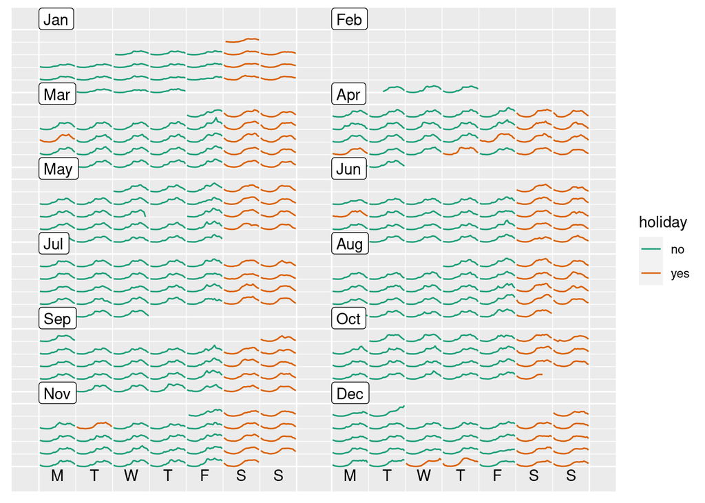

```r
walk_holiday_calendar <- frame_calendar(data = walk_holiday,
                                        x = Time,
                                        y = Count,
                                        date = Date,
                                        nrow = 6)

p3 <- ggplot(walk_holiday_calendar,
       aes(x = .Time,
           y = .Count,
           group = Date,
           colour = holiday)) +
  geom_line() +
  scale_colour_brewer(palette = "Dark2")
prettify(p3)
```

> Now, go to `knitr::opts_chunk` at line 9, change `eval = TRUE`, then knit the document.

### What to do if you are stuck?

- Read through the lecture slides again, they most likely have an answer to these questions!
- Take the question and copy-paste it into google, adding “lubridate” to the google query.